# Sostenibilidad 25

cláusula del 15 %: 14 de 90 operario-semanas; capacidad 13 con inicios más tempranos y 16 tras nivelar (máx. 1/semana); art. 202 LCSP

# Enunciado

Una empresa constructora ha resultado adjudicataria de una obra pública. El pliego incluye, como **condición especial de ejecución** de carácter social calificada de **obligación contractual esencial**, que **al menos el 15 % de las operario-semanas** de la obra las realicen personas en situación de desempleo de larga duración contratadas para la obra a través del servicio público de empleo, con una penalidad de 5 k€ por cada punto porcentual no alcanzado y resolución del contrato si no se alcanza la mitad. El cuadro de prelaciones, las duraciones (semanas), los operarios de cada actividad y si la actividad admite personal de inserción sin cualificación específica (`apta` = 1: peonaje, desbroce, acopios, limpieza, ayudas) se adjuntan.

Tabla 1: Cuadro de datos del enunciado

| activity | predecessor | duration | resources | apta |
| --- | --- | --- | --- | --- |
| A | --- | 1 | 4 | 1 |
| B | --- | 3 | 4 | 1 |
| C | A | 4 | 3 | 1 |
| D | A | 7 | 2 | 1 |
| E | C | 4 | 3 | 1 |
| F | B,E | 4 | 3 | 1 |
| G | D,E | 7 | 1 | 0 |
| H | G | 3 | 3 | 0 |
| I | F,G | 4 | 2 | 0 |

El servicio de empleo y el plan de formación permiten incorporar como máximo **1 persona de inserción por semana** (cada una necesita un tutor en la cuadrilla); cada operario-semana de inserción cuesta 0.3 k€ más que uno ordinario (tutoría, formación y rendimiento inicial).

> **De: Director de producción** Eso se cubre en el papel: la subcontrata de pintura dice que su gente es de inserción y listo, o contamos a los peones de siempre, que alguno estuvo en paro. Y si no, se lo pasamos a la subcontrata en su contrato, que para eso está. No voy a parar la obra por una cláusula social.

## Criterio de referencia

Las preguntas del bloque **B** se responden aplicando los criterios siguientes, tomados de la lección 20 (redactados por el curso; cada uno remite a la fuente de la que procede, que no se reproduce). La respuesta se justifica citando el criterio y la fuente, no con una opinión.

- **S14 — Condiciones especiales de ejecución del contrato.** Una condición especial de ejecución de tipo social o ambiental fijada en el pliego es una obligación del contrato, no una recomendación: se planifica como el alcance, se verifica con documentación y su incumplimiento lleva penalidad o, si el pliego la califica de esencial, resolución. Se exige igualmente a los subcontratistas, de modo que trasladar la obligación a la cadena no la cumple ni la elimina. Si el plan la cumple o no es un cálculo (operarios-semana, kWh, toneladas) con los datos del enunciado. *(cf. LCSP (Ley 9/2017), art. 202.1 a 202.4; ICB4, Perspectiva 3 «cumplimiento, estándares y regulaciones».)*
- **S10 — Condiciones de trabajo en la cadena de ejecución.** El plan no puede apoyarse en condiciones de trabajo que la norma prohíbe: ni en una cadena de subcontratación más larga que la permitida, ni en jornadas al aire libre que ignoren los avisos por calor extremo. Una ventaja de coste o plazo obtenida así no es una opción de la tabla (cf. C7 y C5 de la lección 19). *(cf. Ley 32/2006 de subcontratación en la construcción, arts. 4 y 5; RD 486/1997, disposición adicional única (RDL 4/2023); ICB4, Perspectiva 3 «salud, seguridad y medio ambiente».)*
- **Norma o dato de referencia — el pliego debe incluir al menos una condición especial de ejecución de tipo medioambiental, social o relativa a la innovación (por ejemplo, combatir el paro, en particular el juvenil o el de larga duración, o la igualdad en el empleo); los pliegos pueden fijar penalidades por su incumplimiento o calificarlas de obligaciones contractuales esenciales a efectos de resolución, y todas se exigen igualmente a los subcontratistas que participen en la ejecución** *(Ley 9/2017 (LCSP), art. 202.1, 202.2, 202.3 y 202.4.)*

Responda a las preguntas: A (cálculo), B (criterio) y C (deliberación).

1. 1. Con el diagrama de cargas de inicios más tempranos, calcule las operario-semanas totales de la obra, las que exige la cláusula (15 %) y la capacidad máxima de operario-semanas de inserción (semana a semana, el mínimo entre 1 y la carga de las actividades aptas). ¿Cumple el plan? Nivele las cargas dentro de las holguras y repita el cálculo.

2. 1. Calcule el coste de cumplir la cláusula (operario-semanas de inserción por su sobrecoste) y el coste de no cumplirla con el plan de inicios más tempranos (puntos de déficit por la penalidad). ¿Cuánto cuesta la cláusula frente a la penalidad?

3. 2. Según el criterio y la norma de referencia, ¿es la condición una obligación o una recomendación? ¿La cumple el plan con inicios más tempranos? ¿Y tras nivelar? ¿Vale trasladarla a la subcontrata o «cubrirla en el papel»?

4. 3. ¿Qué propone al director de producción y qué comunica al responsable del contrato? Aplique la rúbrica.

# Resolución

Cálculo de los tiempos tempranos y tardíos de los sucesos y de las holguras totales paso a paso. El primer paso muestra el grafo resuelto; a partir del siguiente se calcula desde el principio (avance con los botones):

[figure not shown]

paso 0 de 32

[figure not shown]

Figura 1: Grafo PERT del proyecto

## Apartado 1

1. 1. Con el diagrama de cargas de inicios más tempranos, calcule las operario-semanas totales de la obra, las que exige la cláusula (15 %) y la capacidad máxima de operario-semanas de inserción (semana a semana, el mínimo entre 1 y la carga de las actividades aptas). ¿Cumple el plan? Nivele las cargas dentro de las holguras y repita el cálculo.

[figure not shown]

Figura 2: Gantt con inicios más tempranos y carga de operarios

Tabla 2: Carga total, carga de las actividades aptas y capacidad de inserción, semana a semana (inicios más tempranos)

|  | 1 | 2 | 3 | 4 | 5 | 6 | 7 | 8 | 9 | 10 | 11 | 12 | 13 | 14 | 15 | 16 | 17 | 18 | 19 | 20 | Total |
| --- | --- | --- | --- | --- | --- | --- | --- | --- | --- | --- | --- | --- | --- | --- | --- | --- | --- | --- | --- | --- | --- |
| carga total | 8 | 9 | 9 | 5 | 5 | 5 | 5 | 5 | 3 | 4 | 4 | 4 | 4 | 1 | 1 | 1 | 5 | 5 | 5 | 2 | 90 |
| carga de las aptas | 8 | 9 | 9 | 5 | 5 | 5 | 5 | 5 | 3 | 3 | 3 | 3 | 3 | 0 | 0 | 0 | 0 | 0 | 0 | 0 | 66 |
| inserción posible (mín con 1) | 1 | 1 | 1 | 1 | 1 | 1 | 1 | 1 | 1 | 1 | 1 | 1 | 1 | 0 | 0 | 0 | 0 | 0 | 0 | 0 | 13 |

Operario-semanas de la obra = suma de la carga total = **90**; la cláusula exige al menos 15 % × 90 = 13.5, es decir, **14** operario-semanas (redondeando hacia arriba). La capacidad de inserción de cada semana es mín(1, carga de las aptas); sumada, **13** operario-semanas = 13 / 90 = 14.4% de la obra.

**Respuesta:** con inicios más tempranos el plan **no cumple** (13 < 14): las actividades aptas se solapan: en 13 semanas su carga supera el máximo de 1 y el exceso se desperdicia, y 7 semanas no tienen ninguna actividad apta.

Tabla 3: Desplazamientos de la nivelación y capacidad de inserción tras nivelar

|  | desplazamientos |
| --- | --- |
| B | 9 |

|  | 1 | 2 | 3 | 4 | 5 | 6 | 7 | 8 | 9 | 10 | 11 | 12 | 13 | 14 | 15 | 16 | 17 | 18 | 19 | 20 | Total |
| --- | --- | --- | --- | --- | --- | --- | --- | --- | --- | --- | --- | --- | --- | --- | --- | --- | --- | --- | --- | --- | --- |
| carga de las aptas (nivelada) | 4 | 5 | 5 | 5 | 5 | 5 | 5 | 5 | 3 | 4 | 4 | 4 | 3 | 3 | 3 | 3 | 0 | 0 | 0 | 0 | 66 |
| inserción posible (mín con 1) | 1 | 1 | 1 | 1 | 1 | 1 | 1 | 1 | 1 | 1 | 1 | 1 | 1 | 1 | 1 | 1 | 0 | 0 | 0 | 0 | 16 |

La nivelación (de la carga total, dentro de las holguras) desplaza B 9 semanas (apta): reparte la carga apta en más semanas, y la capacidad de inserción sube a **16** operario-semanas (17.8%) con la misma duración (20 semanas).

**Respuesta:** tras nivelar, **cumple** la cláusula (16 ≥ 14).

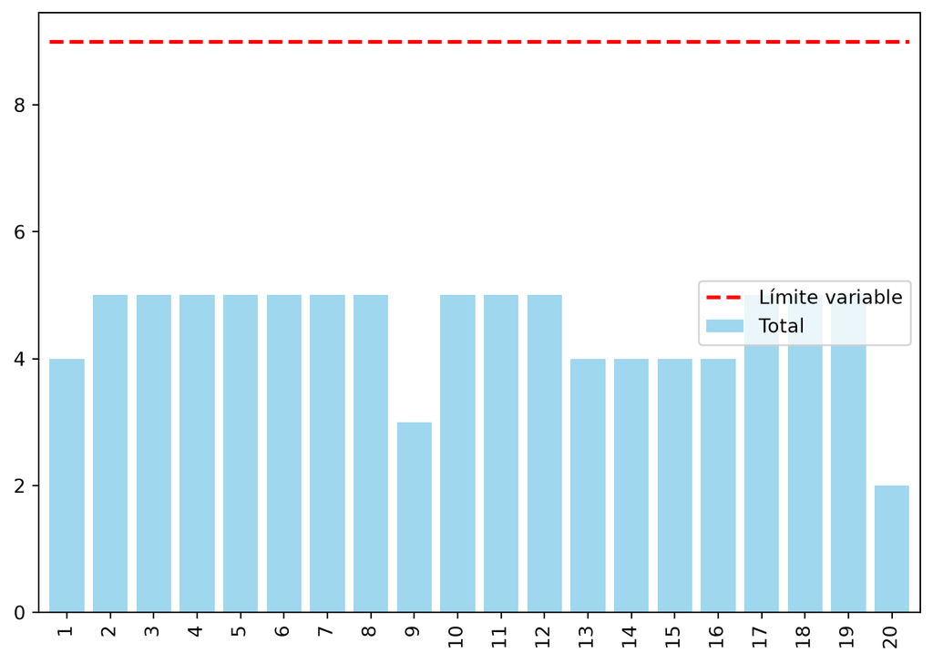

Figura 3: Diagrama de cargas tras la nivelación

## Apartado 2

2. 1. Calcule el coste de cumplir la cláusula (operario-semanas de inserción por su sobrecoste) y el coste de no cumplirla con el plan de inicios más tempranos (puntos de déficit por la penalidad). ¿Cuánto cuesta la cláusula frente a la penalidad?

Tabla 4: Coste de cumplir frente a coste de no cumplir

|  | valor |
| --- | --- |
| cumplir tras nivelar: sobrecoste de tutoría (k€) | 4.20 |
| plan inicial sin nivelar: déficit (operario-semanas) | 1.00 |
| plan inicial sin nivelar: déficit (puntos porcentuales) | 0.56 |
| plan inicial sin nivelar: penalidad (k€) | 2.78 |

- Cumplir (plan nivelado): 14 operario-semanas de inserción × 0.3 k€ = **4.2 k€** de tutoría, con una nivelación que no alarga la obra.

- No cumplir (plan inicial): se alcanza el 13 / 90 = 14.44 % frente al 15 % exigido; faltan 15 − 14.44 = **0.56 puntos** (1 operario-semana hasta las 14), y la penalidad es 0.56 × 5 = **2.8 k€** (no hay causa de resolución: 14.44 % supera la mitad del 15 %).

**Respuesta:** la cláusula cuesta 4.2 k€ y la penalidad de no cumplirla con el plan inicial sería 2.8 k€: la penalidad sería menor, pero la cláusula es una obligación esencial del contrato, no una opción que se compra (apartado 3).

## Apartado 3

3. 2. Según el criterio y la norma de referencia, ¿es la condición una obligación o una recomendación? ¿La cumple el plan con inicios más tempranos? ¿Y tras nivelar? ¿Vale trasladarla a la subcontrata o «cubrirla en el papel»?

**Norma y S14.** La condición especial de ejecución es una **obligación del contrato** (LCSP, art. 202): el pliego la ha calificado de esencial, de modo que su incumplimiento lleva la penalidad y, por debajo de la mitad, la resolución (art. 202.3). Se exige igualmente a los subcontratistas (art. 202.4): pasarla a la subcontrata **no la traslada**, la extiende; y «cubrirla en el papel» con personal que no cumple la definición del pliego es una afirmación falsa en la certificación (lección 19, C1), además de incumplir. Si el plan la cumple es un cálculo: con inicios más tempranos la capacidad es de 13 operario-semanas frente a las 14 exigidas (**no cumple**, 0.56 puntos de déficit); tras nivelar, 16 (**cumple**), con la misma duración. **S10.** El plan no puede apoyarse en una contratación que la norma y el contrato no permiten: la opción «en el papel» no está en la tabla, y la de nivelar sí.

**Respuesta:** es una **obligación** del contrato (esencial); el plan con inicios más tempranos **no** la cumple y el nivelado **sí**; trasladarla a la subcontrata no la cumple (se exige también a ella) y «cubrirla en el papel» es falsear la certificación.

**1. Una condición especial de ejecución de tipo social fijada en el pliego…**

- ✅ es una obligación del contrato, con penalidad o resolución si el pliego la califica de esencial

- ◻️ es una recomendación

- ◻️ sólo obliga si el contratista la aceptó expresamente en su oferta

- ◻️ se sustituye por una compensación económica

*S14: LCSP art. 202.1 y 202.3.*

**2. Las condiciones especiales de ejecución, respecto a los subcontratistas…**

- ✅ se exigen igualmente a todos los que participen en la ejecución (art. 202.4)

- ◻️ no les afectan

- ◻️ sólo si el contrato principal lo dice

- ◻️ sólo a los de primer nivel

*Art. 202.4 de la LCSP.*

**3. La capacidad máxima de operario-semanas de inserción con q personas por semana es…**

- ✅ la suma, semana a semana, del mínimo entre q y la carga de las actividades aptas

- ◻️ q por la duración del proyecto

- ◻️ q por el número de actividades aptas

- ◻️ el total de operario-semanas de las actividades aptas

*El límite semanal desperdicia la carga que se solapa: nivelar la reparte.*

## Apartado 4

4. 3. ¿Qué propone al director de producción y qué comunica al responsable del contrato? Aplique la rúbrica.

La pregunta del bloque C es abierta: no tiene una respuesta única y se evalúa el **procedimiento**: (1) identificar a todos los afectados, incluidos los que no están en la mesa (la comunidad, los trabajadores de la cadena, quien opere o desmantele lo construido, las generaciones siguientes) y qué pierde o gana cada uno con las cifras del bloque A; (2) formular al menos dos alternativas además de la propuesta, situándolas en la pirámide (compensar, restaurar, minimizar, evitar); (3) someter cada alternativa a tres pruebas —legalidad (¿cumple la norma?), publicidad (¿la defendería ante el inspector, el cliente o la prensa?) y ciclo de vida (¿quién paga el impacto y cuándo?)—; (4) decidir y redactar la comunicación con las cifras. Una respuesta que sólo opina, sin cifras ni alternativas, no supera la rúbrica.

Al director de producción: la tabla del apartado 1 nivelada, con las semanas y actividades en las que entran las personas de inserción (1 como máximo por semana), el calendario de incorporación con el servicio de empleo (hay que pedirlas con antelación) y el coste (4.2 k€) frente a la penalidad (2.8 k€). Al responsable del contrato: el plan de cumplimiento con la documentación que se aportará (contratos, certificados del servicio de empleo, partes de trabajo), y a las subcontratas, la cláusula en su contrato porque la ley lo exige, no para deshacerse de ella. Prueba de publicidad: ¿firmaría la certificación con la lista de «inserción» de la subcontrata de pintura?